# Get started with pipeflow

## A simple example to get started

In this example, we’ll use base R’s airquality dataset.

```r
head(airquality)
#   Ozone Solar.R Wind Temp Month Day
# 1    41     190  7.4   67     5   1
# 2    36     118  8.0   72     5   2
# 3    12     149 12.6   74     5   3
# 4    18     313 11.5   62     5   4
# 5    NA      NA 14.3   56     5   5
# 6    28      NA 14.9   66     5   6
```

Our goal is to create an analysis pipeline that performs the following steps:

- add new data column `Temp.Celsius` containing the temperature in degrees Celsius
- fit a linear model to the data
- plot the data and the model fit.

In the following, we’ll show how to define and run the pipeline, how to inspect the output of specific steps, and finally how to re-run the pipeline with different parameter settings, which is one of the selling points of using such a pipeline.

### Pipeline building

```r
library(pipeflow)

pip <- pip_new("my-pip")

pip <- pip_add(
    pip,
    step = "data",
    fun = function(data = airquality) data
)
```

For each step, at minimum we specify the name of the step (here `step = "data`) and a function (`fun`) that defines what is computed in that step. Let’s take a first look at the pipeline.

```r
pip
# <pipeflow> my-pip (1 step)
# --------------------------
#    step params depends state
# 1: data   data           new
# --------------------------
# <ready> last run: never
```

Each step is represented by one row in the table, which currently shows four columns:

- `step` the name of the step
- `params` the names of the function parameters
- `depends` the dependencies of a step (more on that below)
- `state` the state of each step, which initially is always set to `new`

Next, we want to add a step called `prep`, which prepares our original data by adding the new column `"Temp.Celsius"`. This means, our `prep` step will have to use the output of the `data` step. To refer to the output of an earlier pipeline step, we just write its name preceded with the tilde (~) operator, which in this case means `~data`.

Since `pip_add` works “by reference”, we can add the step as follows:

```r
pip |> pip_add(
    "prep",
    function(df = ~data) {
        df[, "Temp.Celsius"] <- (df[, "Temp"] - 32) * 5 / 9
        df
    }
)
```

To reiterate: `function(df = ~data)` basically means that once this function gets called `df` will contain whatever was produced last by the `data` step.

So, a second step called `prep` was added and it depends on the `data` step, which is also marked in the 2nd row in column `depends`.

```r
pip
# <pipeflow> my-pip (2 steps)
# ---------------------------
#    step params depends state
# 1: data   data           new
# 2: prep     df    data   new
# ---------------------------
# <ready> last run: never
```

Next, we want to add a step called `fit` that fits a linear model to the data. The function is using the `prep`ared data and defines a parameter `xVar`, which determines the variable that is used as predictor in the linear model.

```r
pip |> pip_add(
    "fit",
    function(data = ~prep,
             xVar = "Temp.Celsius") {
        lm(paste("Ozone ~", xVar), data = data)
    }
)

pip
# <pipeflow> my-pip (3 steps)
# ---------------------------
#    step    params depends state
# 1: data      data           new
# 2: prep        df    data   new
# 3:  fit data,xVar    prep   new
# ---------------------------
# <ready> last run: never
```

Lastly, we add a step called `plot`, which plots the data and the linear model fit. This function references both the `fit` and `prep` step. As in the previous step, it defines the `xVar` parameter plus two more plot-specific parameters `xLab` and `title`.

```r
pip |> pip_add(
    "plot",
    function(model = ~fit,
             data = ~prep,
             xVar = "Temp.Celsius",
             xLab = "Temperature in degrees Celsius",
             title = "Linear model fit") {
        require(ggplot2, quietly = TRUE)
        coeffs <- coefficients(model)
        ggplot(data) +
            geom_point(aes(.data[[xVar]], .data[["Ozone"]])) +
            geom_abline(intercept = coeffs[1], slope = coeffs[2]) +
            labs(title = title, x = xLab)
    }
)
```

In the `depends` column of row `4:`, we see that the `plot` step depends on both the `fit` and the `prep` step.

```r
pip
# <pipeflow> my-pip (4 steps)
# ---------------------------
#    step                     params  depends state
# 1: data                       data            new
# 2: prep                         df     data   new
# 3:  fit                  data,xVar     prep   new
# 4: plot model,data,xVar,xLab,title fit,prep   new
# ---------------------------
# <ready> last run: never
```

In addition to the tabular output, {pipeflow} also provides a graphical representation that is compatible with the `visNetwork` package. The `pip_graph()` function returns a list of arguments that can be feed directly to `visNetwork::visNetwork()`.

```r
library(visNetwork)
do.call(visNetwork, args = pip_graph(pip)) |>
    visHierarchicalLayout(direction = "LR")
```

[interactive chart not shown]

Here, the pipeline is visualized as a directed acyclic graph (DAG) where the nodes represent the steps and the edges represent the dependencies.

### Pipeline integrity

A key feature of {pipeflow} is that the integrity of a pipeline is verified at definition time. To see this, let’s try to add another step that referencing step that does not exist in the pipeline.

```r
pip |> pip_add(
    "another_step",
    function(x = ~upsi) {
        x
    }
)
# Error:
# ! while adding step 'another_step' - cannot reference unknown steps: 'upsi'
```

{pipeflow} immediately signals an error and the pipeline remains unchanged.

```r
pip
# <pipeflow> my-pip (4 steps)
# ---------------------------
#    step                     params  depends state
# 1: data                       data            new
# 2: prep                         df     data   new
# 3:  fit                  data,xVar     prep   new
# 4: plot model,data,xVar,xLab,title fit,prep   new
# ---------------------------
# <ready> last run: never
```

### Pipeline run and output

To run the pipeline, we simply call `pip_run()`, which produces the following output:

```r
pip_run(pip)
# info [2026-10-13 14:15:31.850 UTC]: Starting run of pipeflow 'my-pip'
# info [2026-10-13 14:15:31.850 UTC]: Step 1/4 data
# info [2026-10-13 14:15:31.854 UTC]: Step 2/4 prep
# info [2026-10-13 14:15:31.859 UTC]: Step 3/4 fit
# info [2026-10-13 14:15:31.866 UTC]: Step 4/4 plot
# info [2026-10-13 14:15:32.413 UTC]: Finished run of pipeflow 'my-pip'
```

Let’s inspect the pipeline again.

```r
pip
# <pipeflow> my-pip (4 steps)
# ---------------------------
#    step                     params  depends state                 out
# 1: data                       data           done <data.frame[153x6]>
# 2: prep                         df     data  done <data.frame[153x7]>
# 3:  fit                  data,xVar     prep  done            <lm[13]>
# 4: plot model,data,xVar,xLab,title fit,prep  done   <ggplot2::ggplot>
# ---------------------------
# <ready> last run: 2026-10-13 16:15:32
```

[interactive chart not shown]

We can see that the `state` of all steps have been changed from `new` to `done`, which graphically is represented by the color change from blue to green.

In addition, the output was added in a new `out` column[^1]. To access a single value of the pipeline, we just select the row (aka step) and a column of the pipeline table via the `[[` operator. For example, to inspect the `out`put of the `fit` and `plot` steps, we do:

```r
pip[["fit", "out"]]
#
# Call:
# lm(formula = paste("Ozone ~", xVar), data = data)
#
# Coefficients:
#  (Intercept)  Temp.Celsius
#      -69.277         4.372
```

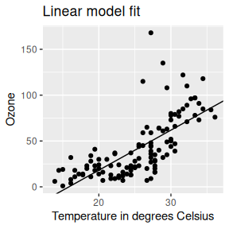

```r
pip[["plot", "out"]]
```

### Pipeline parameters

Even for a moderately complex analysis consisting of, say, 15 to 20 different functions, keeping track of all the different analysis parameters can quickly get out of hand.

As we will see, with {pipeflow} this becomes much easier, since the pipeline itself keeps track of all parameters and their values. Let’s first inspect the parameters of the above defined pipeline using the `pip_get_params()` function.

```r
pip_get_params(pip) |> str()
# List of 4
#  $ data :'data.frame':    153 obs. of  6 variables:
#   ..$ Ozone  : int [1:153] 41 36 12 18 NA 28 23 19 8 NA ...
#   ..$ Solar.R: int [1:153] 190 118 149 313 NA NA 299 99 19 194 ...
#   ..$ Wind   : num [1:153] 7.4 8 12.6 11.5 14.3 14.9 8.6 13.8 20.1 8.6 ...
#   ..$ Temp   : int [1:153] 67 72 74 62 56 66 65 59 61 69 ...
#   ..$ Month  : int [1:153] 5 5 5 5 5 5 5 5 5 5 ...
#   ..$ Day    : int [1:153] 1 2 3 4 5 6 7 8 9 10 ...
#  $ xVar : chr "Temp.Celsius"
#  $ xLab : chr "Temperature in degrees Celsius"
#  $ title: chr "Linear model fit"
```

It returns a list of all *unbound* parameters (here `data, xVar, xLab, title`). By *unbound* we mean that the values of these parameters don’t depend on other steps (i.e. parameters defined with the `~` operator) and therefore can be adjusted freely.

Also note that each parameter is only listed once, even if it’s used in multiple steps[^2]. To change parameters, we simply call `pip_set_params()`:

```r
pip |>
    pip_set_params(list(xVar = "Solar.R", xLab = "Solar radiation in Langleys"))

pip_get_params(pip) |> str()
# List of 4
#  $ data :'data.frame':    153 obs. of  6 variables:
#   ..$ Ozone  : int [1:153] 41 36 12 18 NA 28 23 19 8 NA ...
#   ..$ Solar.R: int [1:153] 190 118 149 313 NA NA 299 99 19 194 ...
#   ..$ Wind   : num [1:153] 7.4 8 12.6 11.5 14.3 14.9 8.6 13.8 20.1 8.6 ...
#   ..$ Temp   : int [1:153] 67 72 74 62 56 66 65 59 61 69 ...
#   ..$ Month  : int [1:153] 5 5 5 5 5 5 5 5 5 5 ...
#   ..$ Day    : int [1:153] 1 2 3 4 5 6 7 8 9 10 ...
#  $ xVar : chr "Solar.R"
#  $ xLab : chr "Solar radiation in Langleys"
#  $ title: chr "Linear model fit"
```

{pipeflow} automatically propagates new parameter values to all steps that use it. In addition, it will recognize which steps are affected by the parameter change and mark them as `outdated` (see column `state`).

```r
pip
# <pipeflow> my-pip (4 steps)
# ---------------------------
#    step                     params  depends    state                 out
# 1: data                       data              done <data.frame[153x6]>
# 2: prep                         df     data     done <data.frame[153x7]>
# 3:  fit                  data,xVar     prep outdated            <lm[13]>
# 4: plot model,data,xVar,xLab,title fit,prep outdated   <ggplot2::ggplot>
# ---------------------------
# <ready> last run: 2026-10-13 16:15:32
```

[interactive chart not shown]

We can see that the `fit` and `plot` steps are now in state `outdated`, because the `xVar` and `xLab` parameters were updated. To update the results, we just run the pipeline again.

```r
pip_run(pip)
# info [2026-10-13 14:15:35.744 UTC]: Starting run of pipeflow 'my-pip'
# info [2026-10-13 14:15:35.744 UTC]: Step 1/4 data - skipping done step
# info [2026-10-13 14:15:35.744 UTC]: Step 2/4 prep - skipping done step
# info [2026-10-13 14:15:35.744 UTC]: Step 3/4 fit
# info [2026-10-13 14:15:35.747 UTC]: Step 4/4 plot
# info [2026-10-13 14:15:35.756 UTC]: Finished run of pipeflow 'my-pip'
```

A closer look at the run log shows that the pipeline skipped the first two steps and ran only the steps that were outdated, which basically can be thought of caching or mimicking the behavior of `make` in software development. That is, {pipeflow} always keeps track of the step states and only re-runs those where its necessary. This can be a huge time saver in larger pipelines[^3].

After the re-run, we can see that the output was updated accordingly now showing the new x-variable `Solar.R`.

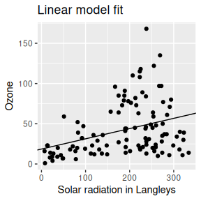

```r
pip[["plot", "out"]]
```

Let’s visit some more examples of parameter changes and their effects on the pipeline. To just change the title of the plot, only the `plot` step needs to be rerun.

```r
pip |> pip_set_params(list(title = "Some new title"))
pip
# <pipeflow> my-pip (4 steps)
# ---------------------------
#    step                     params  depends    state                 out
# 1: data                       data              done <data.frame[153x6]>
# 2: prep                         df     data     done <data.frame[153x7]>
# 3:  fit                  data,xVar     prep     done            <lm[13]>
# 4: plot model,data,xVar,xLab,title fit,prep outdated   <ggplot2::ggplot>
# ---------------------------
# <ready> last run: 2026-10-13 16:15:35
```

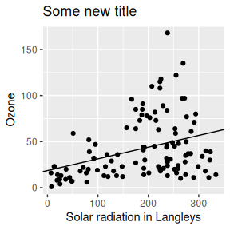

```r
pip_run(pip)
# info [2026-10-13 14:15:36.960 UTC]: Starting run of pipeflow 'my-pip'
# info [2026-10-13 14:15:36.961 UTC]: Step 1/4 data - skipping done step
# info [2026-10-13 14:15:36.961 UTC]: Step 2/4 prep - skipping done step
# info [2026-10-13 14:15:36.961 UTC]: Step 3/4 fit - skipping done step
# info [2026-10-13 14:15:36.961 UTC]: Step 4/4 plot
# info [2026-10-13 14:15:36.972 UTC]: Finished run of pipeflow 'my-pip'
pip[["plot", "out"]]
```

Once we change the input data parameter from the `data` step, since all other steps depend on it, we expect all steps to be rerun.

```r
small_airquality <- airquality[1:10, ]
pip |> pip_set_params(list(data = small_airquality))
pip
# <pipeflow> my-pip (4 steps)
# ---------------------------
#    step                     params  depends    state                 out
# 1: data                       data          outdated <data.frame[153x6]>
# 2: prep                         df     data outdated <data.frame[153x7]>
# 3:  fit                  data,xVar     prep outdated            <lm[13]>
# 4: plot model,data,xVar,xLab,title fit,prep outdated   <ggplot2::ggplot>
# ---------------------------
# <ready> last run: 2026-10-13 16:15:36
```

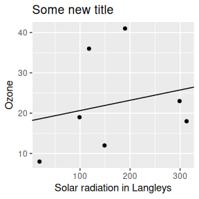

```r
pip_run(pip)
# info [2026-10-13 14:15:38.345 UTC]: Starting run of pipeflow 'my-pip'
# info [2026-10-13 14:15:38.345 UTC]: Step 1/4 data
# info [2026-10-13 14:15:38.347 UTC]: Step 2/4 prep
# info [2026-10-13 14:15:38.351 UTC]: Step 3/4 fit
# info [2026-10-13 14:15:38.353 UTC]: Step 4/4 plot
# info [2026-10-13 14:15:38.363 UTC]: Finished run of pipeflow 'my-pip'
pip[["plot", "out"]]
```

#### Setting Identical Values

Setting a parameter to the value it already has is not a change, so {pipeflow} leaves the step states alone and nothing needs to be re-run. This is handy for apps that pass on all inputs whenever just one of them changed.

```r
pip |> pip_set_params(list(title = "Some new title", data = small_airquality))
pip
# <pipeflow> my-pip (4 steps)
# ---------------------------
#    step                     params  depends state                out
# 1: data                       data           done <data.frame[10x6]>
# 2: prep                         df     data  done <data.frame[10x7]>
# 3:  fit                  data,xVar     prep  done           <lm[13]>
# 4: plot model,data,xVar,xLab,title fit,prep  done  <ggplot2::ggplot>
# ---------------------------
# <ready> last run: 2026-10-13 16:15:38
```

If you do want to outdate the steps anyway, for example because a parameter is an environment that was modified in place, use `force = TRUE`.

```r
pip |> pip_set_params(list(title = "Some new title"), force = TRUE)
pip
# <pipeflow> my-pip (4 steps)
# ---------------------------
#    step                     params  depends    state                out
# 1: data                       data              done <data.frame[10x6]>
# 2: prep                         df     data     done <data.frame[10x7]>
# 3:  fit                  data,xVar     prep     done           <lm[13]>
# 4: plot model,data,xVar,xLab,title fit,prep outdated  <ggplot2::ggplot>
# ---------------------------
# <ready> last run: 2026-10-13 16:15:38
```

#### Handling Unknown Parameters

Last but not least let’s try to set a parameter that doesn’t exist in the pipeline.

```r
pip |> pip_set_params(list(title = "warn me", foo = "my foo"))
# Warning in pip_set_params(pip, list(title = "warn me", foo = "my foo")): Trying to set parameters
# not defined in the target: foo

pip_get_params(pip)$title
# [1] "warn me"
```

By default, all existing parameters are set, and a warning is given to the user notifying about the unknown parameter names. If you set parameters programmatically and know that some of them are not used by the pipeline, you can silence the warning via `unknown = "ignore"`.

```r
pip |> pip_set_params(list(foo = "ignore me"), unknown = "ignore")

pip_get_params(pip)$title
# [1] "warn me"
```

On the other hand, if an unknown parameter should never go unnoticed, use `unknown = "error"`. In this case, nothing is changed at all, not even the valid parameters:

```r
pip |> pip_set_params(
    list(title = "Not set", foo = "my foo"),
    unknown = "error"
)
# Error:
# ! Trying to set parameters not defined in the target: foo
pip_get_params(pip)$title
# [1] "warn me"
```

Next, let’s see how to modify the pipeline.

[^1]: Technically, the `out` column was there all the time but {pipeflow} just did not display it while it was still empty.
[^2]: For example, the `xVar` parameter is used in both the `fit` and `plot` step
[^3]: Another use case is backend computation in interactive shiny applications, where users change parameters dynamically and want quick updates.